# ezDAFi: How To Use

Pedro Milanez-Almeida

1/29/2020

### Visual Guide On How To Use With Example

Population that we will cluster: CD8-CD4+.

Gates that we will refine with DAFi:

- “nonTreg”
- “CD45-RA, CD185 subset” among nonTregs
- “Treg”

[figure not shown]

After selecting population of interest, click on “Workspace”, “plugins” and “DAFi”. Select parameters for clustering among other options.

[figure not shown]

After hitting OK, the plugin runs for a few seconds (about 10-20sec for default number of clusters; the first run may take a few minutes to install packages). Derived parameters and gated populations are imported back into FlowJo automatically. Please Note how the plugin ran DAFi on the whole tree down from “CD8-CD4+” (this behavior can be turned off to DAFi only the immediate children).

[figure not shown]

DAFi populations behave just like FlowJo native populations! They can be plotted, gated, used in layouts and stats! Please note, however, that one cannot call the plugin on a children or children of children of a previous DAFi gate, yet.

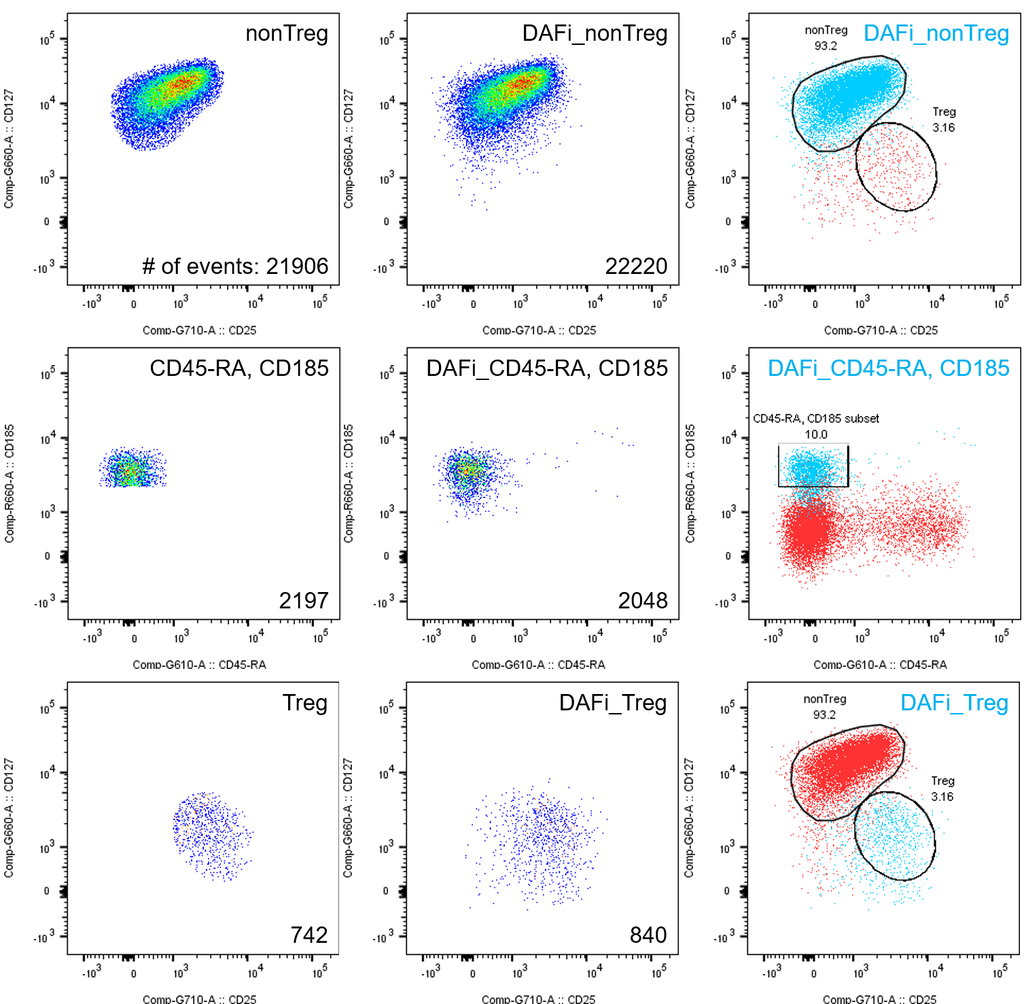